# Final Project

Data Science for Biologists, Spring 2021

Lucy Lithgow

## Introduction

[Fast food calories dataset](https://github.com/rfordatascience/tidytuesday/blob/master/data/2018/2018-09-04/fastfood_calories.csv): The fast food dataset includes 8 unique fast food restaurants and information on their menu items including calories, sodium, fat, sugar, protein and more. I selected this dataset because it has a lot of information to work with and it will be interesting to compare the nutrition facts from different popular fast food chains, or compare the menu items from within the same restaurant.

```r
fastfood <- readr::read_csv('https://raw.githubusercontent.com/rfordatascience/tidytuesday/master/data/2018/2018-09-04/fastfood_calories.csv')

glimpse(fastfood)
```

```
## Rows: 515
## Columns: 18
## $ X1          <dbl> 1, 2, 3, 4, 5, 6, 7, 8, 9, 10, 11, 12, 13, 14, 15, 16, 17…
## $ restaurant  <chr> "Mcdonalds", "Mcdonalds", "Mcdonalds", "Mcdonalds", "Mcdo…
## $ item        <chr> "Artisan Grilled Chicken Sandwich", "Single Bacon Smokeho…
## $ calories    <dbl> 380, 840, 1130, 750, 920, 540, 300, 510, 430, 770, 380, 6…
## $ cal_fat     <dbl> 60, 410, 600, 280, 410, 250, 100, 210, 190, 400, 170, 300…
## $ total_fat   <dbl> 7, 45, 67, 31, 45, 28, 12, 24, 21, 45, 18, 34, 20, 34, 8,…
## $ sat_fat     <dbl> 2.0, 17.0, 27.0, 10.0, 12.0, 10.0, 5.0, 4.0, 11.0, 21.0, …
## $ trans_fat   <dbl> 0.0, 1.5, 3.0, 0.5, 0.5, 1.0, 0.5, 0.0, 1.0, 2.5, 0.0, 1.…
## $ cholesterol <dbl> 95, 130, 220, 155, 120, 80, 40, 65, 85, 175, 40, 95, 125,…
## $ sodium      <dbl> 1110, 1580, 1920, 1940, 1980, 950, 680, 1040, 1040, 1290,…
## $ total_carb  <dbl> 44, 62, 63, 62, 81, 46, 33, 49, 35, 42, 38, 48, 48, 67, 3…
## $ fiber       <dbl> 3, 2, 3, 2, 4, 3, 2, 3, 2, 3, 2, 3, 3, 5, 2, 2, 3, 3, 5, …
## $ sugar       <dbl> 11, 18, 18, 18, 18, 9, 7, 6, 7, 10, 5, 11, 11, 11, 6, 3, …
## $ protein     <dbl> 37, 46, 70, 55, 46, 25, 15, 25, 25, 51, 15, 32, 42, 33, 1…
## $ vit_a       <dbl> 4, 6, 10, 6, 6, 10, 10, 0, 20, 20, 2, 10, 10, 10, 2, 4, 6…
## $ vit_c       <dbl> 20, 20, 20, 25, 20, 2, 2, 4, 4, 6, 0, 10, 20, 15, 2, 6, 1…
## $ calcium     <dbl> 20, 20, 50, 20, 20, 15, 10, 2, 15, 20, 15, 35, 35, 35, 4,…
## $ salad       <chr> "Other", "Other", "Other", "Other", "Other", "Other", "Ot…
```

## Question 1

#### Which fast food restaurant has the highest average calories per menu item?

### Methods

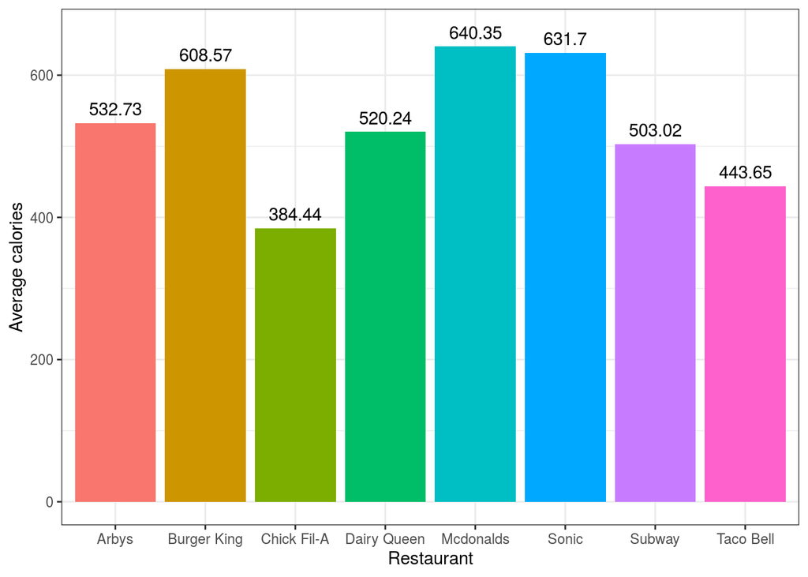

```r
fastfood %>%
  group_by(restaurant) %>% #add grouping
  summarise(mean_calories = mean(calories)) %>% #find mean calories per restaurant
  ggplot() +
  aes(x = restaurant, #restaurant on x axis
      y = mean_calories, #mean calories on y axis
      fill = restaurant) + #map restaurant to fill
  geom_col() + #histogram
  geom_text(aes(label = round(mean_calories, digits = 2), #label each mean calories and round
                y = mean_calories +20), check_overlap = T) + #move label and remove overlap
  theme_bw() + #set theme
  labs(x = "Restaurant",
       y = "Average calories") + #rename axis
  scale_color_brewer() + #set color theme
  theme(legend.position = "none") #remove legend
```

### Answer

The McDonald’s menu contains the items with the highest average calories.

## Question 2

#### Which fast food signature sandwhich is highest in calories?

### Methods

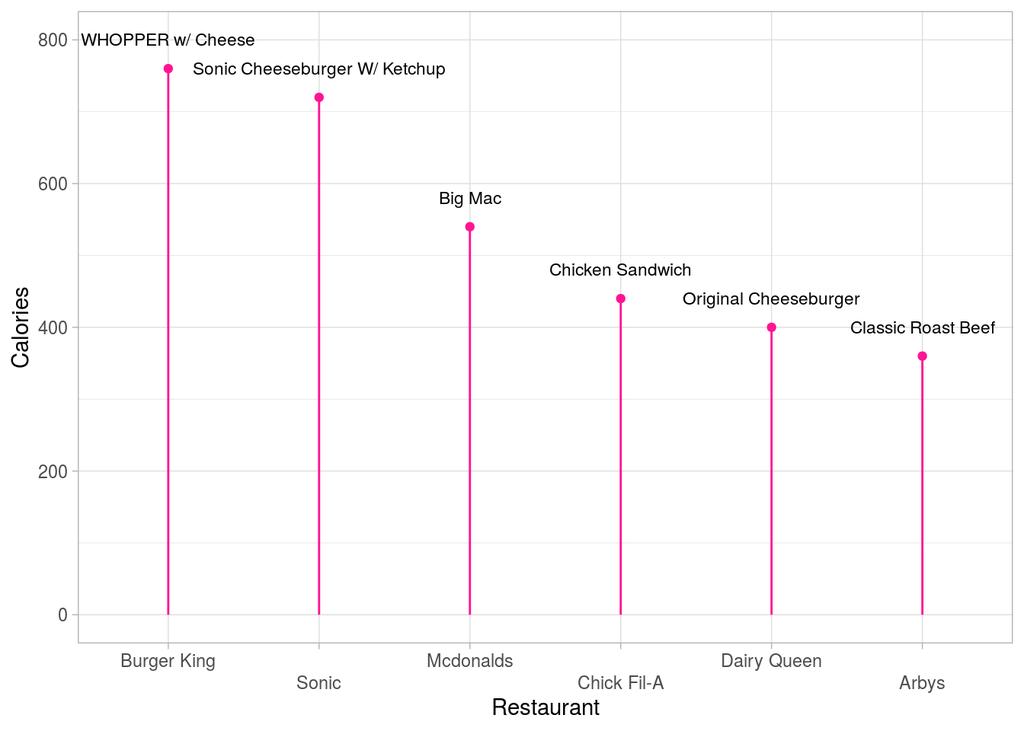

```r
fastfood %>%
  filter(item %in% c("Big Mac", "Chicken Sandwich", "Sonic Cheeseburger W/ Ketchup", "Classic Roast Beef", "WHOPPER w/ Cheese", "Original Cheeseburger")) %>%
  ggplot() +
  aes (x = reorder(restaurant, -calories),
       y = calories) +
  geom_point(color = "deeppink") +
  geom_segment(color = "deeppink",
    aes(x = restaurant,
               y = 0,
               xend = restaurant,
               yend = calories)) +
  scale_x_discrete(guide = guide_axis(n.dodge = 2)) +
  scale_color_brewer() +
  geom_text( size = 3,
    aes(label = item,
            y = calories + 40)) +
  theme_light() +
  labs(x = "Restaurant",
       y = "Calories")
```

### Answer

The Whopper with cheese from Burger King is highest in calories compared to other fast food restaurant’s signature sandwiches.

## Question 3

#### Which restaurant has the lowest average trans fat per menu item?

### Methods

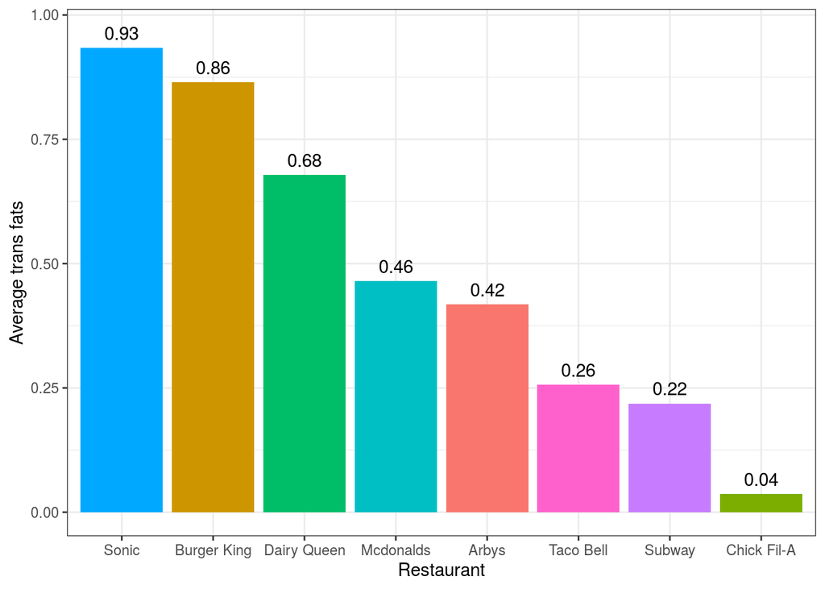

```r
fastfood %>%
  group_by(restaurant) %>%
  summarise(mean_transfat = mean(trans_fat)) %>%
  ggplot() +
  aes(x = reorder(restaurant, -mean_transfat),
      y = mean_transfat,
      fill = restaurant) +
  geom_col() +
  geom_text(aes(label = round(mean_transfat, digits = 2),
                y = mean_transfat + .03)) +
  theme_bw() +
  labs(x = "Restaurant",
       y = "Average trans fats") +
  scale_color_brewer() +
  theme(legend.position = "none")
```

### Answer

Chick Fil-A’s menu items on average have the lowest trans fats.

## Question 4

#### Which restaurant’s chicken menu items are a better source of protein, Mcdonald’s or Chick Fil-A?

### Methods

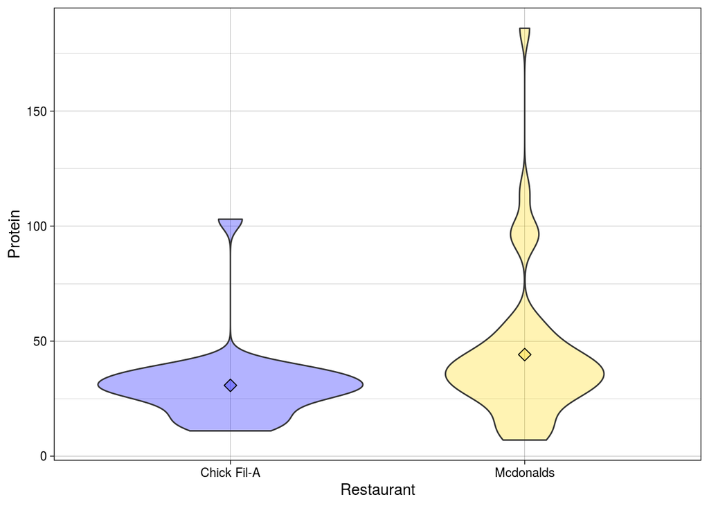

```r
fastfood %>%
  filter(restaurant %in% c("Mcdonalds", "Chick Fil-A")) -> restaurants

restaurants %>%
  filter(X1 %in% c(1,4,5, 8, 13, 14, 18, 19, 20, 24, 25, 26, 27, 30, 31, 33:82)) -> justchicken

justchicken %>%
  ggplot() +
  aes(x = restaurant,
      y = protein,
      fill = restaurant) +
  geom_violin() +
  scale_fill_manual(values = alpha(c("blue", "gold"), .3)) +
  stat_summary(fun = mean, geom ="point", shape=23, size=3) +
  theme_linedraw() +
  labs(x = "Restaurant",
       y = "Protein") +
  theme(legend.position = "none")
```

### Answer

The average protein value for chicken based menu items is higher at Mcdonald’s compared to Chick Fil-A.